# Case Study - (Bella Beat) How Can a Wellness Technology Company Play It Smart?

This is a capstone project for Google Data Analytics Professional Certificate Course

Bellabeat is a high-tech manufacturer of beautifully-designed health-focused smart products for women since 2013. Inspiring and empowering women with knowledge about their own health and habits, Bellabeat has grown rapidly and quickly positioned itself as a tech-driven wellness company for females.

The co-founder and Chief Creative Officer, Urška Sršen is confident that an analysis of non-Bellebeat consumer data (ie. FitBit fitness tracker usage data) would reveal more opportunities for growth.

I will be using 6 phases for the analysis such as Ask, Prepare, Process, Analyse, Share and Act.

# Phase 1: ASK

### Business Task Summary:

**Analyzing Smart Device Fitness Data:**

The junior data analyst is tasked with analyzing smart device data related to Bellabeat's products. This analysis aims to uncover insights into consumer behavior and usage patterns of smart wellness devices like the Leaf, Time, and Spring. The goal is to identify trends and patterns in how consumers interact with these devices through the Bellabeat app. This data will provide valuable insights that can inform Bellabeat's marketing strategies.

**Developing Marketing Strategy Recommendations:**

Based on the analysis of smart device data, the data analyst must formulate high-level recommendations for Bellabeat's marketing strategy. These recommendations should align with Bellabeat's mission of empowering women with health-focused technology and capitalize on the identified consumer trends. The aim is to propose strategic initiatives that enhance customer engagement, improve product relevance, and drive growth in the smart device market.

**Key Stakeholders:**

Urška Sršen: As Bellabeat's cofounder and Chief Creative Officer, Sršen drives the company's vision and growth strategy. She has prioritized the analysis of smart device data to unlock new growth opportunities.

Sando Mur: As a mathematician and cofounder, Mur plays a crucial role in strategic decision-making. He will likely be involved in evaluating and implementing the marketing strategy recommendations derived from the data analysis.

Bellabeat Marketing Analytics Team: This team, including the junior data analyst, is responsible for collecting, analyzing, and interpreting data to support Bellabeat's marketing initiatives. Their insights will shape how Bellabeat engages with its customers and markets its products effectively.

Bellabeat Customers: Ultimately, the insights gained from the data analysis will impact Bellabeat's customers. The goal is to enhance customer satisfaction by tailoring marketing efforts to better meet their health and wellness needs.

# Phase 2: Prepare

**Determine the credibility of the data**

The following files are selected for analysis using Python as downloaded from kaggle:

- dailyActivity_merged.csv
- sleepDay_merged.csv
- heartrate_seconds_merged.csv

## Import neccessary libraries

```python
import numpy as np
import pandas as pd
import seaborn as sns
import matplotlib.pyplot as plt
import warnings
warnings.filterwarnings("ignore")
%matplotlib inline
```

## Load the dataset

```python
daily_activity_df = pd.read_csv('data/dailyActivity_merged.csv')
sleep_day_df = pd.read_csv('data/sleepDay_merged.csv')
heart_rate_df = pd.read_csv('data/heartrate_seconds_merged.csv')
```

# Phase 3: Process

## Data cleaning

### Handling missing value

```python
# Change column name to lower case for ease of use
daily_activity_df.columns = daily_activity_df.columns.str.lower()
sleep_day_df.columns = sleep_day_df.columns.str.lower()
heart_rate_df.columns = heart_rate_df.columns.str.lower()
```

```python
# Store dataframes in a dictionary
df_dict = {
    'Daily Activity': daily_activity_df,
    'Sleep Day': sleep_day_df,
    'Heart Rate': heart_rate_df
}
```

```python
# Check for missing values
for name, df in df_dict.items():
    print(f"{name} Missing Values:")
    print(df.isnull().sum())
```

```
Daily Activity Missing Values:
id                          0
activitydate                0
totalsteps                  0
totaldistance               0
trackerdistance             0
loggedactivitiesdistance    0
veryactivedistance          0
moderatelyactivedistance    0
lightactivedistance         0
sedentaryactivedistance     0
veryactiveminutes           0
fairlyactiveminutes         0
lightlyactiveminutes        0
sedentaryminutes            0
calories                    0
dtype: int64
Sleep Day Missing Values:
id                    0
sleepday              0
totalsleeprecords     0
totalminutesasleep    0
totaltimeinbed        0
dtype: int64
Heart Rate Missing Values:
id       0
time     0
value    0
dtype: int64
```

### Remove duplicates

```python
# Drop duplicate and reset index
for name, df in df_dict.items():
    df.drop_duplicates(inplace=True)
    df.reset_index(inplace=True, drop=True)
```

### Handling outliers

```python
def remove_outliers(df):
    """
    Remove outliers from a DataFrame based on the IQR method.
    """
    # Select numeric column
    numeric_cols = df.select_dtypes(include=['number']).columns
    df_numeric = df[numeric_cols]

    # Calculate Q1 and Q3
    Q1 = df_numeric.quantile(0.25)
    Q3 = df_numeric.quantile(0.75)
    IQR = Q3 - Q1

    # Remove outlier
    condition = ~((df_numeric < (Q1 - 1.5 * IQR)) | (df_numeric > (Q3 + 1.5 * IQR))).any(axis=1)
    df = df[condition]

    return df
```

```python
remove_outliers(daily_activity_df) # Test function
```

|  | id | activitydate | totalsteps | totaldistance | trackerdistance | loggedactivitiesdistance | veryactivedistance | moderatelyactivedistance | lightactivedistance | sedentaryactivedistance | veryactiveminutes | fairlyactiveminutes | lightlyactiveminutes | sedentaryminutes | calories |
| --- | --- | --- | --- | --- | --- | --- | --- | --- | --- | --- | --- | --- | --- | --- | --- |
| 0 | 1503960366 | 4/12/2016 | 13162 | 8.50 | 8.50 | 0.0 | 1.88 | 0.55 | 6.06 | 0.0 | 25 | 13 | 328 | 728 | 1985 |
| 1 | 1503960366 | 4/13/2016 | 10735 | 6.97 | 6.97 | 0.0 | 1.57 | 0.69 | 4.71 | 0.0 | 21 | 19 | 217 | 776 | 1797 |
| 2 | 1503960366 | 4/14/2016 | 10460 | 6.74 | 6.74 | 0.0 | 2.44 | 0.40 | 3.91 | 0.0 | 30 | 11 | 181 | 1218 | 1776 |
| 3 | 1503960366 | 4/15/2016 | 9762 | 6.28 | 6.28 | 0.0 | 2.14 | 1.26 | 2.83 | 0.0 | 29 | 34 | 209 | 726 | 1745 |
| 4 | 1503960366 | 4/16/2016 | 12669 | 8.16 | 8.16 | 0.0 | 2.71 | 0.41 | 5.04 | 0.0 | 36 | 10 | 221 | 773 | 1863 |
| ... | ... | ... | ... | ... | ... | ... | ... | ... | ... | ... | ... | ... | ... | ... | ... |
| 928 | 8877689391 | 5/1/2016 | 10930 | 8.32 | 8.32 | 0.0 | 3.13 | 0.57 | 4.57 | 0.0 | 36 | 12 | 166 | 1226 | 2786 |
| 929 | 8877689391 | 5/2/2016 | 4790 | 3.64 | 3.64 | 0.0 | 0.00 | 0.00 | 3.56 | 0.0 | 0 | 0 | 105 | 1335 | 2189 |
| 935 | 8877689391 | 5/8/2016 | 10686 | 8.11 | 8.11 | 0.0 | 1.08 | 0.20 | 6.80 | 0.0 | 17 | 4 | 245 | 1174 | 2847 |
| 937 | 8877689391 | 5/10/2016 | 10733 | 8.15 | 8.15 | 0.0 | 1.35 | 0.46 | 6.28 | 0.0 | 18 | 11 | 224 | 1187 | 2832 |
| 939 | 8877689391 | 5/12/2016 | 8064 | 6.12 | 6.12 | 0.0 | 1.82 | 0.04 | 4.25 | 0.0 | 23 | 1 | 137 | 770 | 1849 |

671 rows × 15 columns

```python
# Apply function to all dataframe
for name, df in df_dict.items():
    print(f"{name} removed outliers:")
    remove_outliers(df)
    print(df)
```

```
Daily Activity removed outliers:
             id activitydate  totalsteps  totaldistance  trackerdistance  \
0    1503960366    4/12/2016       13162       8.500000         8.500000
1    1503960366    4/13/2016       10735       6.970000         6.970000
2    1503960366    4/14/2016       10460       6.740000         6.740000
3    1503960366    4/15/2016        9762       6.280000         6.280000
4    1503960366    4/16/2016       12669       8.160000         8.160000
..          ...          ...         ...            ...              ...
935  8877689391     5/8/2016       10686       8.110000         8.110000
936  8877689391     5/9/2016       20226      18.250000        18.250000
937  8877689391    5/10/2016       10733       8.150000         8.150000
938  8877689391    5/11/2016       21420      19.559999        19.559999
939  8877689391    5/12/2016        8064       6.120000         6.120000

     loggedactivitiesdistance  veryactivedistance  moderatelyactivedistance  \
```

[output cut: 82 more lines]

## Data summary

```python
# Data summary
for name, df in df_dict.items():
    print(f"Data summary for {name}:")
    print(f"{name} unique values: {df.id.nunique()}")
    print(df.info())
    print(df.describe())
    print('\n ********************************** \n')
```

```
Data summary for Daily Activity:
Daily Activity unique values: 33
<class 'pandas.core.frame.DataFrame'>
RangeIndex: 940 entries, 0 to 939
Data columns (total 15 columns):
 #   Column                    Non-Null Count  Dtype
---  ------                    --------------  -----
 0   id                        940 non-null    int64
 1   activitydate              940 non-null    object
 2   totalsteps                940 non-null    int64
 3   totaldistance             940 non-null    float64
 4   trackerdistance           940 non-null    float64
 5   loggedactivitiesdistance  940 non-null    float64
 6   veryactivedistance        940 non-null    float64
 7   moderatelyactivedistance  940 non-null    float64
 8   lightactivedistance       940 non-null    float64
 9   sedentaryactivedistance   940 non-null    float64
 10  veryactiveminutes         940 non-null    int64
 11  fairlyactiveminutes       940 non-null    int64
 12  lightlyactiveminutes      940 non-null    int64
 13  sedentaryminutes          940 non-null    int64
 14  calories                  940 non-null    int64
dtypes: float64(7), int64(7), object(1)
memory usage: 110.3+ KB
None
                 id    totalsteps  totaldistance  trackerdistance  \
count  9.400000e+02    940.000000     940.000000       940.000000
mean   4.855407e+09   7637.910638       5.489702         5.475351
std    2.424805e+09   5087.150742       3.924606         3.907276
min    1.503960e+09      0.000000       0.000000         0.000000
25%    2.320127e+09   3789.750000       2.620000         2.620000
50%    4.445115e+09   7405.500000       5.245000         5.245000
75%    6.962181e+09  10727.000000       7.712500         7.710000
max    8.877689e+09  36019.000000      28.030001        28.030001

       loggedactivitiesdistance  veryactivedistance  moderatelyactivedistance  \
count                940.000000          940.000000                940.000000
mean                   0.108171            1.502681                  0.567543
std                    0.619897            2.658941                  0.883580
min                    0.000000            0.000000                  0.000000
```

[output cut: 69 more lines]

```
 0   id      int64
 1   time    object
 2   value   int64
dtypes: int64(2), object(1)
memory usage: 56.8+ MB
None
                 id         value
count  2.483658e+06  2.483658e+06
mean   5.513765e+09  7.732842e+01
std    1.950224e+09  1.940450e+01
min    2.022484e+09  3.600000e+01
25%    4.388162e+09  6.300000e+01
50%    5.553957e+09  7.300000e+01
75%    6.962181e+09  8.800000e+01
max    8.877689e+09  2.030000e+02
```

## Feature engineering

### Daily Activity

```python
# Create weekday and total active minutes column for further analysis
daily_activity_df.rename(columns={'activitydate':'date'}, inplace=True)
daily_activity_df.date = pd.to_datetime(daily_activity_df.date)
daily_activity_df['weekday'] = daily_activity_df.date.dt.day_name()
daily_activity_df['total_active_minutes']=daily_activity_df.fairlyactiveminutes + daily_activity_df.lightlyactiveminutes + daily_activity_df.veryactiveminutes

# daily_activity_df.to_csv('daily_activity_update.csv', index=False) # enable if needed
daily_activity_df.head()
```

|  | id | date | totalsteps | totaldistance | trackerdistance | loggedactivitiesdistance | veryactivedistance | moderatelyactivedistance | lightactivedistance | sedentaryactivedistance | veryactiveminutes | fairlyactiveminutes | lightlyactiveminutes | sedentaryminutes | calories | weekday | total_active_minutes |
| --- | --- | --- | --- | --- | --- | --- | --- | --- | --- | --- | --- | --- | --- | --- | --- | --- | --- |
| 0 | 1503960366 | 2016-04-12 | 13162 | 8.50 | 8.50 | 0.0 | 1.88 | 0.55 | 6.06 | 0.0 | 25 | 13 | 328 | 728 | 1985 | Tuesday | 366 |
| 1 | 1503960366 | 2016-04-13 | 10735 | 6.97 | 6.97 | 0.0 | 1.57 | 0.69 | 4.71 | 0.0 | 21 | 19 | 217 | 776 | 1797 | Wednesday | 257 |
| 2 | 1503960366 | 2016-04-14 | 10460 | 6.74 | 6.74 | 0.0 | 2.44 | 0.40 | 3.91 | 0.0 | 30 | 11 | 181 | 1218 | 1776 | Thursday | 222 |
| 3 | 1503960366 | 2016-04-15 | 9762 | 6.28 | 6.28 | 0.0 | 2.14 | 1.26 | 2.83 | 0.0 | 29 | 34 | 209 | 726 | 1745 | Friday | 272 |
| 4 | 1503960366 | 2016-04-16 | 12669 | 8.16 | 8.16 | 0.0 | 2.71 | 0.41 | 5.04 | 0.0 | 36 | 10 | 221 | 773 | 1863 | Saturday | 267 |

### Heart Rate

```python
# Heart rate
heart_rate_df.time = pd.to_datetime(heart_rate_df.time)
heart_rate_df['weekday'] = heart_rate_df.time.dt.day_name()
heart_rate_df['date'] = heart_rate_df.time.dt.date
heart_rate_df['hour'] = heart_rate_df.time.dt.time
```

```python
# Create weekday, date, time, session column for further analysis
def session(time):
    hour = time.hour
    if 5 <= hour < 12:
        return 'morning'
    if 12 <= hour < 17:
        return 'afternoon'
    if 17 <= hour < 21:
        return 'evening'
    else:
        return 'night'

heart_rate_df['session'] = heart_rate_df.time.apply(session)
heart_rate_df.drop(columns='time', inplace=True)
heart_rate_df = heart_rate_df.rename(columns={'hour':'time'})

# heart_rate_df.to_csv('hear_rate_updated.csv', index=False) # enable if needed
heart_rate_df.head()
```

|  | id | value | weekday | date | time | session |
| --- | --- | --- | --- | --- | --- | --- |
| 0 | 2022484408 | 97 | Tuesday | 2016-04-12 | 07:21:00 | morning |
| 1 | 2022484408 | 102 | Tuesday | 2016-04-12 | 07:21:05 | morning |
| 2 | 2022484408 | 105 | Tuesday | 2016-04-12 | 07:21:10 | morning |
| 3 | 2022484408 | 103 | Tuesday | 2016-04-12 | 07:21:20 | morning |
| 4 | 2022484408 | 101 | Tuesday | 2016-04-12 | 07:21:25 | morning |

```python
# Create heart rate mean dataframe
heart_rate_mean = heart_rate_df.groupby(['id', 'weekday','date'])['value'].mean()
heart_rate_mean = heart_rate_mean.reset_index()
heart_rate_mean = heart_rate_mean.rename(columns={'value': 'avgheartrate'})
heart_rate_mean.head()
```

|  | id | weekday | date | avgheartrate |
| --- | --- | --- | --- | --- |
| 0 | 2022484408 | Friday | 2016-04-15 | 80.437382 |
| 1 | 2022484408 | Friday | 2016-04-22 | 80.125444 |
| 2 | 2022484408 | Friday | 2016-04-29 | 83.412873 |
| 3 | 2022484408 | Friday | 2016-05-06 | 81.722098 |
| 4 | 2022484408 | Monday | 2016-04-18 | 82.712829 |

### Sleep

```python
# Create weekday, date, time column for further analysis
sleep_day_df['sleepday'] = pd.to_datetime(sleep_day_df.sleepday)
sleep_day_df['weekday'] = sleep_day_df.sleepday.dt.day_name()
sleep_day_df['date'] = sleep_day_df.sleepday.dt.date
sleep_day_df['time'] = sleep_day_df.sleepday.dt.time
sleep_day_df = sleep_day_df.drop('sleepday', axis=1)

# sleep_day_df.to_csv('sleep_day_updated.csv', index=False) # enable if needed
sleep_day_df.head()
```

|  | id | totalsleeprecords | totalminutesasleep | totaltimeinbed | weekday | date | time |
| --- | --- | --- | --- | --- | --- | --- | --- |
| 0 | 1503960366 | 1 | 327 | 346 | Tuesday | 2016-04-12 | 00:00:00 |
| 1 | 1503960366 | 2 | 384 | 407 | Wednesday | 2016-04-13 | 00:00:00 |
| 2 | 1503960366 | 1 | 412 | 442 | Friday | 2016-04-15 | 00:00:00 |
| 3 | 1503960366 | 2 | 340 | 367 | Saturday | 2016-04-16 | 00:00:00 |
| 4 | 1503960366 | 1 | 700 | 712 | Sunday | 2016-04-17 | 00:00:00 |

```python
# Create sleep mean dataframe
sleep_mean = sleep_day_df.groupby(['id', 'weekday','date'])[['totalminutesasleep','totaltimeinbed']].mean()
sleep_mean = sleep_mean.reset_index()
sleep_mean.head()
```

|  | id | weekday | date | totalminutesasleep | totaltimeinbed |
| --- | --- | --- | --- | --- | --- |
| 0 | 1503960366 | Friday | 2016-04-15 | 412.0 | 442.0 |
| 1 | 1503960366 | Friday | 2016-04-29 | 341.0 | 354.0 |
| 2 | 1503960366 | Friday | 2016-05-06 | 334.0 | 367.0 |
| 3 | 1503960366 | Monday | 2016-04-25 | 277.0 | 323.0 |
| 4 | 1503960366 | Monday | 2016-05-02 | 277.0 | 309.0 |

### Merge data

```python
# Concat data on the same id, weekday and date
df_all = pd.concat([daily_activity_df.set_index(['id', 'weekday', 'date']),
                       heart_rate_mean.set_index(['id', 'weekday', 'date']),
                       sleep_mean.set_index(['id', 'weekday', 'date'])],
                      axis=1, join='outer')
df_all.head()
```

| id | weekday | date | totalsteps | totaldistance | trackerdistance | loggedactivitiesdistance | veryactivedistance | moderatelyactivedistance | lightactivedistance | sedentaryactivedistance | veryactiveminutes | fairlyactiveminutes | lightlyactiveminutes | sedentaryminutes | calories | total_active_minutes | avgheartrate | totalminutesasleep | totaltimeinbed |
| --- | --- | --- | --- | --- | --- | --- | --- | --- | --- | --- | --- | --- | --- | --- | --- | --- | --- | --- | --- |
| 1503960366 | Tuesday | 2016-04-12 | 13162 | 8.50 | 8.50 | 0.0 | 1.88 | 0.55 | 6.06 | 0.0 | 25 | 13 | 328 | 728 | 1985 | 366 | NaN | 327.0 | 346.0 |
|  | Wednesday | 2016-04-13 | 10735 | 6.97 | 6.97 | 0.0 | 1.57 | 0.69 | 4.71 | 0.0 | 21 | 19 | 217 | 776 | 1797 | 257 | NaN | 384.0 | 407.0 |
|  | Thursday | 2016-04-14 | 10460 | 6.74 | 6.74 | 0.0 | 2.44 | 0.40 | 3.91 | 0.0 | 30 | 11 | 181 | 1218 | 1776 | 222 | NaN | NaN | NaN |
|  | Friday | 2016-04-15 | 9762 | 6.28 | 6.28 | 0.0 | 2.14 | 1.26 | 2.83 | 0.0 | 29 | 34 | 209 | 726 | 1745 | 272 | NaN | 412.0 | 442.0 |
|  | Saturday | 2016-04-16 | 12669 | 8.16 | 8.16 | 0.0 | 2.71 | 0.41 | 5.04 | 0.0 | 36 | 10 | 221 | 773 | 1863 | 267 | NaN | 340.0 | 367.0 |

# Phase 4: Analyze

#### Activity

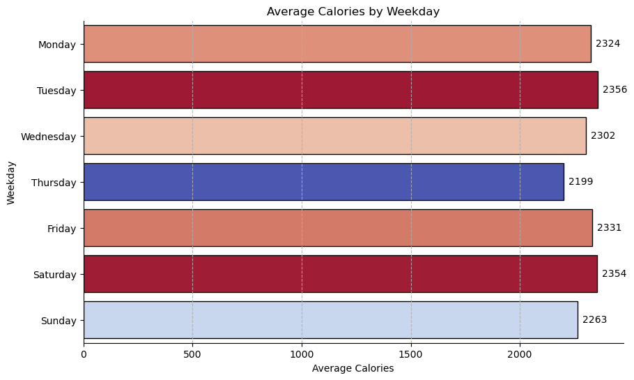

```python
# Calculate the average calories burned each weekday
avg_calories = daily_activity_df.groupby('weekday')['calories'].mean()

# Create weekday oder for the bar plot
weekday_order = ['Monday', 'Tuesday', 'Wednesday', 'Thursday', 'Friday', 'Saturday', 'Sunday']
# Plot bar graph, title, labels
plt.figure(figsize=(10, 6), dpi=100)
ax = sns.barplot(y='weekday', x='calories', data=pd.DataFrame(avg_calories).reset_index(), order=weekday_order, hue='calories', edgecolor="black", palette="coolwarm", legend= False)
plt.ylabel('Weekday')
plt.xlabel('Average Calories')
plt.title('Average Calories by Weekday')
# Annotate bar value
for p in ax.patches:
    ax.annotate(str(int(p.get_width())), (p.get_width(), p.get_y() + p.get_height() / 2.),
                ha='left', va='center', color='black', xytext=(5, 0), textcoords='offset points')
# Add grid lines and remove spines
ax.grid(axis='x', linestyle='--', alpha=0.9)
ax.spines['top'].set_visible(False)
ax.spines['right'].set_visible(False)
ax.yaxis.grid(False)
ax.spines['left'].set_color('black')
ax.spines['bottom'].set_color('black')
plt.savefig('avg_cal_burned_by_weekday.png')
plt.show()
```

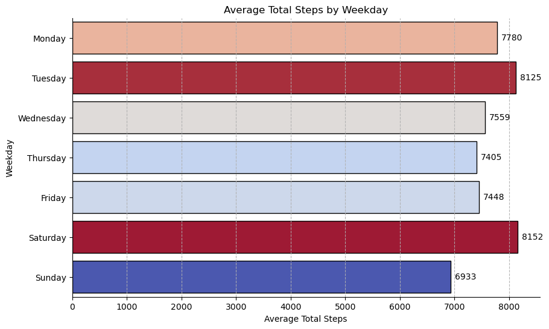

```python
# Calculate the average steps each weekday
avg_step_by_weekday = daily_activity_df.groupby('weekday')['totalsteps'].mean()

# Plot bar graph, title, labels
plt.figure(figsize=(10, 6), dpi=100)
ax = sns.barplot(y='weekday', x='totalsteps', data=pd.DataFrame(avg_step_by_weekday).reset_index(), order=weekday_order, hue='totalsteps', edgecolor="black", palette="coolwarm", legend= False)
plt.ylabel('Weekday')
plt.xlabel('Average Total Steps')
plt.title('Average Total Steps by Weekday')
# Annotate bar value
for p in ax.patches:
    ax.annotate(str(int(p.get_width())), (p.get_width(), p.get_y() + p.get_height() / 2.),
                ha='left', va='center', color='black', xytext=(5, 0), textcoords='offset points')
# Add grid lines and remove spines
ax.grid(axis='x', linestyle='--', alpha=0.9)
ax.spines['top'].set_visible(False)
ax.spines['right'].set_visible(False)
ax.yaxis.grid(False)
ax.spines['left'].set_color('black')
ax.spines['bottom'].set_color('black')
plt.savefig('avg_total_steps_by_weekday.png')
plt.show()
```

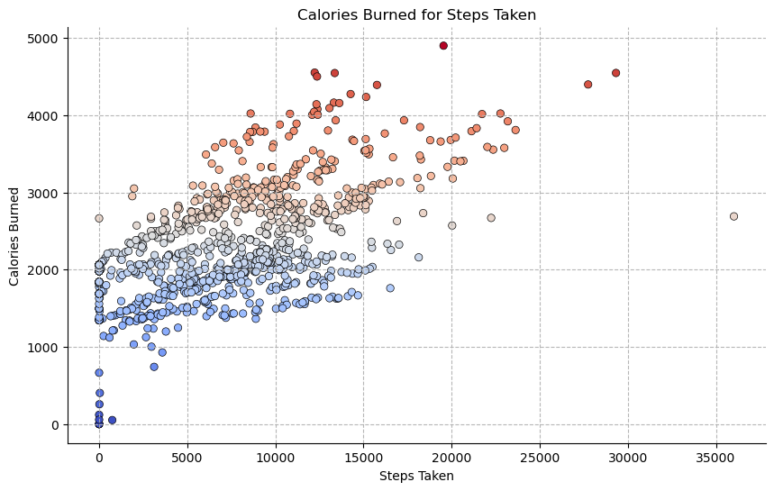

```python
# Scatter plot calories and step taken to see the correlation
plt.figure(figsize=(10, 6), dpi=100)
ax = sns.scatterplot(x='totalsteps', y='calories', data=daily_activity_df, hue='calories', palette='coolwarm', edgecolor="black", legend=False)
plt.xlabel("Steps Taken")
plt.ylabel("Calories Burned")
plt.title("Calories Burned for Steps Taken")

# Add grid lines and remove spines
plt.grid(axis='both', linestyle='--', alpha=0.9)
ax.spines['top'].set_visible(False)
ax.spines['right'].set_visible(False)
ax.spines['left'].set_color('black')
ax.spines['bottom'].set_color('black')
plt.savefig('cal_burned_for_steps.png')
plt.show()
```

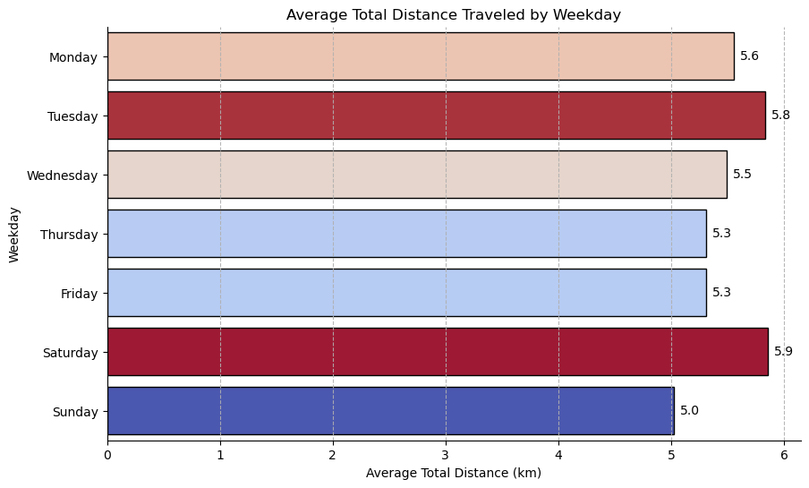

```python
# Calculate the average total distance travel each weekday
avg_total_dist_by_day = daily_activity_df.groupby('weekday')['totaldistance'].mean()

# Plot bar graph, title, labels
plt.figure(figsize=(10, 6), dpi=100)
ax = sns.barplot(y='weekday', x='totaldistance', data=pd.DataFrame(avg_total_dist_by_day).reset_index(), order=weekday_order, hue='totaldistance', edgecolor="black", palette="coolwarm", legend= False)
plt.ylabel('Weekday')
plt.xlabel('Average Total Distance (km)')
plt.title('Average Total Distance Traveled by Weekday')
# Annotate bar value
for p in ax.patches:
    ax.annotate('{:.1f}'.format(p.get_width()), (p.get_width(), p.get_y() + p.get_height() / 2.), ha='left', va='center', color='black', xytext=(5, 0), textcoords='offset points')
# Add grid lines and remove spines
ax.grid(axis='x', linestyle='--', alpha=0.9)
ax.spines['top'].set_visible(False)
ax.spines['right'].set_visible(False)
ax.yaxis.grid(False)
ax.spines['left'].set_color('black')
ax.spines['bottom'].set_color('black')
plt.savefig('avg_total_distance_by_weekday.png')
plt.show()
```

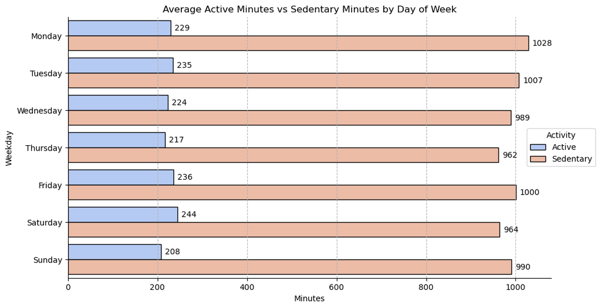

```python
# average activity by weekday
avg_activity_by_day = daily_activity_df.groupby('weekday')[['total_active_minutes', 'sedentaryminutes']].mean()
# Plot bar graph, title, labels
plt.figure(figsize=(11, 6), dpi=100)
ax = sns.barplot(y='weekday', x='value', hue='variable', data=avg_activity_by_day.reset_index().melt(id_vars='weekday'), order=weekday_order, palette="coolwarm", edgecolor="black")
plt.ylabel('Weekday')
plt.xlabel('Minutes')
plt.title('Average Active Minutes vs Sedentary Minutes by Day of Week')

# Annotate bar values
for p in ax.patches:
    if p.get_width() > 0:
        ax.annotate('{:.0f}'.format(p.get_width()), (p.get_width(), p.get_y() + p.get_height() / 2.),
                    ha='left', va='center', color='black', xytext=(5, 0), textcoords='offset points')

# Add grid lines and remove spines
ax.grid(axis='x', linestyle='--', alpha=0.9)
ax.spines['top'].set_visible(False)
ax.spines['right'].set_visible(False)
ax.yaxis.grid(False)
ax.spines['left'].set_color('black')
ax.spines['bottom'].set_color('black')

# Show legend
handles, labels = ax.get_legend_handles_labels()
ax.legend(handles, ['Active', 'Sedentary'], title='Activity', loc='center right', bbox_to_anchor=(1.1, 0.5))
plt.savefig('avg_active_sedentary_by_weekday.png')
plt.show()
```

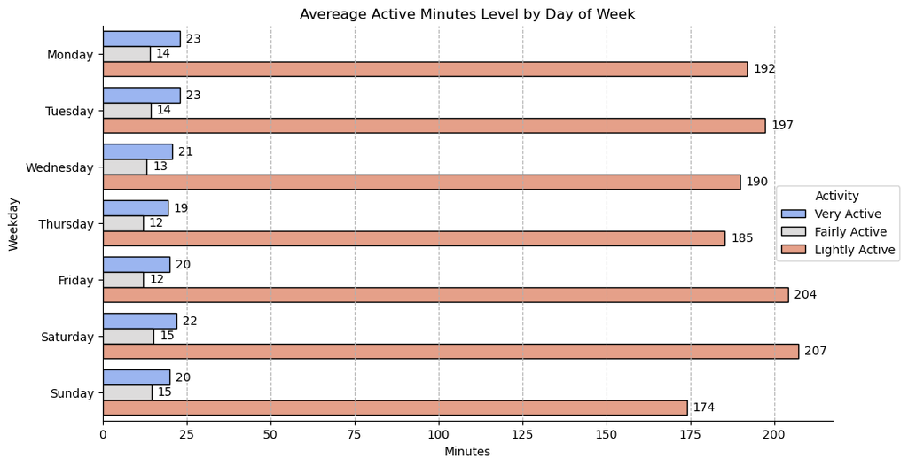

```python
# average activity minutes by level and weekday
avg_active_minutes_by_day = daily_activity_df.groupby('weekday')[['veryactiveminutes', 'fairlyactiveminutes', 'lightlyactiveminutes']].mean()

# Plot bar graph, title, labels
plt.figure(figsize=(11, 6), dpi=100)
ax = sns.barplot(y='weekday', x='value', hue='variable', data=avg_active_minutes_by_day.reset_index().melt(id_vars='weekday'), order=weekday_order, palette="coolwarm", edgecolor="black")
plt.ylabel('Weekday')
plt.xlabel('Minutes')
plt.title('Avereage Active Minutes Level by Day of Week')

# Annotate bar values
for p in ax.patches:
    if p.get_width() > 0:
        ax.annotate('{:.0f}'.format(p.get_width()), (p.get_width(), p.get_y() + p.get_height() / 2.),
                    ha='left', va='center', color='black', xytext=(5, 0), textcoords='offset points')

# Add grid lines and remove spines
ax.grid(axis='x', linestyle='--', alpha=0.9)
ax.spines['top'].set_visible(False)
ax.spines['right'].set_visible(False)
ax.yaxis.grid(False)
ax.spines['left'].set_color('black')
ax.spines['bottom'].set_color('black')

# Show legend
handles, labels = ax.get_legend_handles_labels()
ax.legend(handles, ['Very Active', 'Fairly Active', 'Lightly Active'], title='Activity', loc='center right', bbox_to_anchor=(1.1, 0.5))
plt.savefig('avg_active_level_by_weekday.png')
plt.show()
```

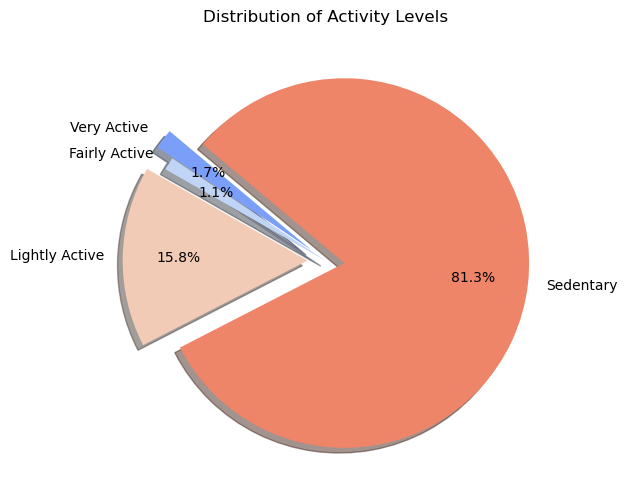

```python
# Total activity minutes by level
very_active_mins = daily_activity_df['veryactiveminutes'].sum()
fairly_active_mins = daily_activity_df['fairlyactiveminutes'].sum()
lightly_active_mins = daily_activity_df['lightlyactiveminutes'].sum()
sedentary_mins = daily_activity_df['sedentaryminutes'].sum()

# Plot and annotate value
plt.figure(figsize=(6, 6), dpi=100)
labels = ['Very Active', 'Fairly Active', 'Lightly Active', 'Sedentary']
sizes = [very_active_mins, fairly_active_mins, lightly_active_mins, sedentary_mins]
explode = [0.1, 0, 0.1, 0.1]
colors = plt.cm.coolwarm([0.2, 0.4, 0.6, 0.8])
plt.pie(sizes, labels=labels, autopct="%1.1f%%", pctdistance=0.7, explode=explode, shadow=True, startangle=140, colors=colors)

# Show legend
plt.title('Distribution of Activity Levels')
plt.savefig('distribution_active_level.png')
plt.show()
```

#### Heart Rate

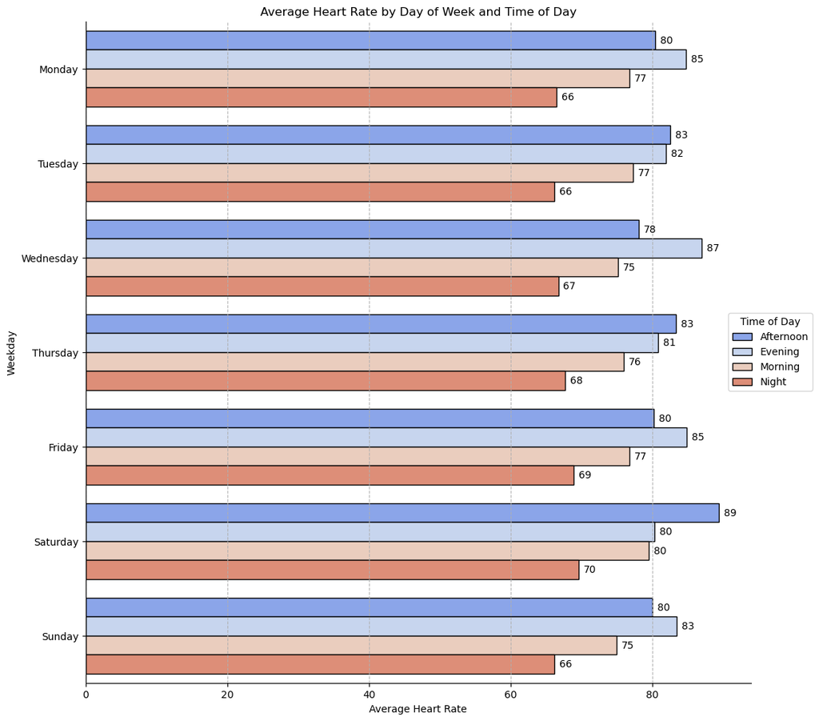

```python
# Average heart rate group by day of week
avg_heartrate = heart_rate_df.groupby(["weekday", "session"])["value"].mean()
avg_heartrate = avg_heartrate.reset_index()
avg_heartrate_melted = avg_heartrate.melt(id_vars=['weekday', 'session'], var_name='time_of_day', value_name='average_heartrate')

# Plot bar graph, title, labels
plt.figure(figsize=(12, 12), dpi=100)
ax = sns.barplot(y='weekday', x='average_heartrate', hue='session', data=avg_heartrate_melted, order=weekday_order, palette="coolwarm", edgecolor="black")
plt.ylabel('Weekday')
plt.xlabel('Average Heart Rate')
plt.title('Average Heart Rate by Day of Week and Time of Day')

# Annotate bar values
for p in ax.patches:
    if p.get_width() > 0:
        ax.annotate('{:.0f}'.format(p.get_width()), (p.get_width(), p.get_y() + p.get_height() / 2.),
                    ha='left', va='center', color='black', xytext=(5, 0), textcoords='offset points')

# Add grid lines and remove spines
ax.grid(axis='x', linestyle='--', alpha=0.9)
ax.spines['top'].set_visible(False)
ax.spines['right'].set_visible(False)
ax.yaxis.grid(False)
ax.spines['left'].set_color('black')
ax.spines['bottom'].set_color('black')

# Show legend
handles, labels = ax.get_legend_handles_labels()
ax.legend(handles, ['Afternoon', 'Evening', 'Morning', 'Night'], title='Time of Day', loc='center right', bbox_to_anchor=(1.1, 0.5))
plt.savefig('avg_heart_rate_by_weekday.png')
plt.show()
```

#### Sleep

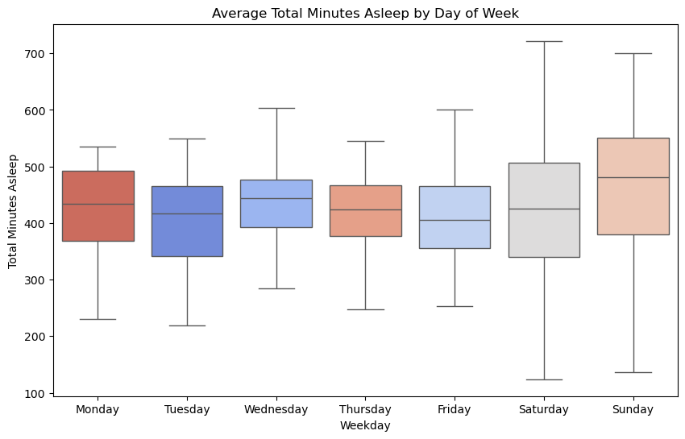

```python
# Average sleep minutes group by day of week
sleep_grouped = sleep_day_df.groupby('weekday')['totalminutesasleep'].mean()
# Plot boxplot
fig, ax = plt.subplots(figsize=(10, 6), dpi=100)
sns.boxplot(x='weekday', y='totalminutesasleep', data=sleep_day_df, order=weekday_order, showfliers=False, ax=ax, palette="coolwarm", hue='weekday', legend= False)

# Add title and labels
plt.title('Average Total Minutes Asleep by Day of Week')
plt.xlabel('Weekday')
plt.ylabel('Total Minutes Asleep')

# Show plot
plt.savefig('avg_total_asleep_by_weekday.png')
plt.show()
```

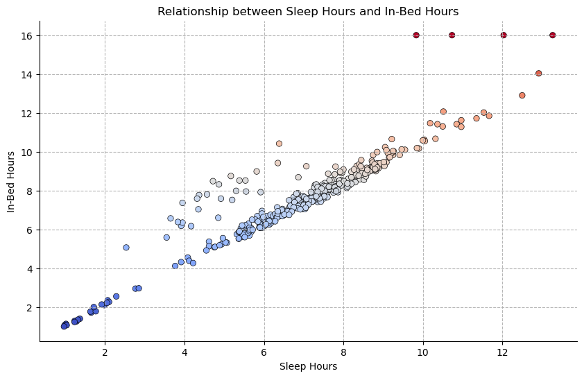

```python
# Create sleep hours and inbed hours column
sleep_day_df['sleephours'] = sleep_day_df.totalminutesasleep /60
sleep_day_df['inbedhours'] =sleep_day_df.totaltimeinbed /60

# Scatter plot
plt.figure(figsize=(10, 6), dpi=100)
ax = sns.scatterplot(x='sleephours', y='inbedhours', data=sleep_day_df, hue='inbedhours', legend=False , palette='coolwarm', edgecolor='black')
plt.xlabel("Sleep Hours")
plt.ylabel("In-Bed Hours")
plt.title("Relationship between Sleep Hours and In-Bed Hours")

# Add grid lines and remove spines
plt.grid(axis='both', linestyle='--', alpha=0.9)
plt.gca().spines['top'].set_visible(False)
plt.gca().spines['right'].set_visible(False)
plt.gca().spines['left'].set_color('black')
plt.gca().spines['bottom'].set_color('black')
plt.savefig('sleep_and_inbed.png')
plt.show()
```

#### Correlation

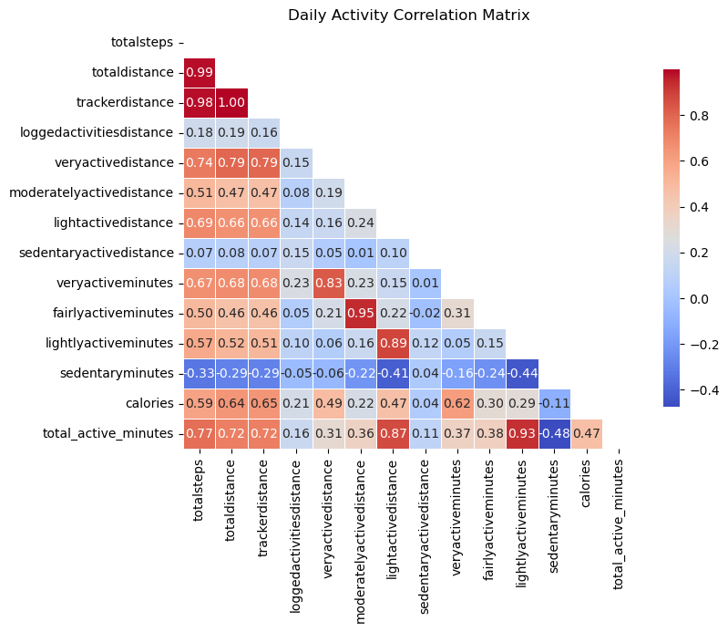

```python
# Correlation between activity
corr = daily_activity_df.drop('id',axis=1).corr(numeric_only=True)

# Create a mask for the upper triangle
mask = np.triu(np.ones_like(corr, dtype=bool))

# Set up the matplotlib figure
plt.figure(figsize=(8, 6), dpi=100)
plt.title("Daily Activity Correlation Matrix")

# Draw the heatmap with the mask and correct aspect ratio
sns.heatmap(corr, mask=mask, cmap='coolwarm', annot=True, fmt='.2f', linewidths=0.5, cbar_kws={"shrink": .8})

# Display the heatmap
plt.show()
```

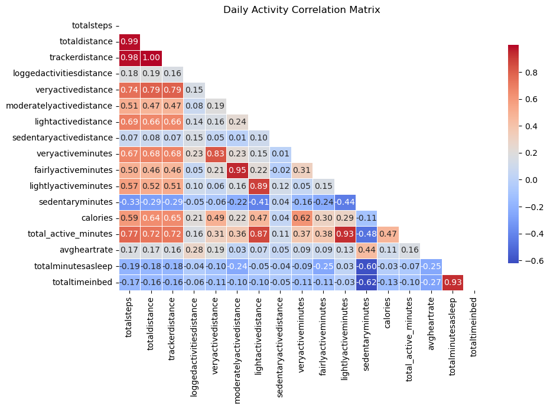

```python
# Correlation between activity, heart rate, and sleep
corr = df_all.corr(numeric_only=True)

# Create a mask for the upper triangle
mask = np.triu(np.ones_like(corr, dtype=bool))

# Set up the matplotlib figure
plt.figure(figsize=(10, 6), dpi=100)
plt.title("Daily Activity Correlation Matrix")

# Draw the heatmap with the mask and correct aspect ratio
sns.heatmap(corr, mask=mask, cmap='coolwarm', annot=True, fmt='.2f', linewidths=0.5, cbar_kws={"shrink": .8})

# Display the heatmap
plt.show()
```

# Phase 5: Share

## Activity

Fitbit trackers measure physical activity in terms of "active minutes," which are the minutes during when you have spent at least 10 minutes in an activity that burns three times as many calories as you do at rest.

Fitbit defines three levels of physical activity:

Lightly Active Minutes: These minutes are logged when you engage in light physical activities that are more intense than just resting but not as intense as brisk walking. This can include activities like slow walking, light household chores, and casual movement.

Fairly Active Minutes: - These minutes are recorded when you participate in activities that are moderately intense. Examples include brisk walking, gardening, or playing with kids. These activities are more vigorous than light activities but not as intense as running or high-intensity workouts.

Very Active Minutes: These are the minutes you spend engaging in activities that are vigorous and significantly raise your heart rate. Examples include running, high-intensity interval training (HIIT), and aerobics.

Fitbit uses sensors to track movements and heart rate, then employs proprietary algorithms to analyze this data and classify activities. The more active you are, the more active minutes you will accumulate.

[figure not shown]

On average, Saturday, Tuesday, and Friday are the most active days, with Monday, Wednesday, Thursday, and Sunday following. People usually get around 20 minutes of very active and 15 minutes of fairly active time each day. However, lightly active minutes vary, with Saturday, Friday, and Tuesday leading, followed by Monday, Wednesday, Thursday, and Sunday.

[figure not shown]

Sedentary minutes account for a significant 81.3% of recorded time, indicating extensive periods of inactivity. Conversely, lightly active minutes, comprising 15.8%. However lightly active minutes significantly differentiate the most active day from the least active one. This suggests that those who engage in more light activities tend to be more active overall.

Given that most active minutes involve light activities, such as outdoor jogging on Saturday and Tuesday, these insights suggest strategies to promote physical activity. Emphasizing outdoor exercises could leverage these days to encourage healthier lifestyles and increased activity levels.

[figure not shown]

In terms of calorie expenditure, Tuesday, Saturday, and Friday stand out as the top three days when people tend to burn the most calories, with Monday, Wednesday, Sunday, and Thursday following in that order. This aligns with the distribution of active minutes across the week, suggesting a correlation between physical activity and calorie burn. Understanding these patterns could inform strategies to promote increased physical activity and calorie expenditure, contributing to better health outcomes.

[figure not shown]

## Heart Rate

[figure not shown]

Analyzing average heart rates by day of the week and time of day reveals patterns in high-intensity exercise. On the most active days, high-intensity workouts are common in the afternoon on Saturday, and in the evening or afternoon on Tuesday. On Friday, these exercises are more often performed in the evening.

These insights can benefit fitness product manufacturers and wellness professionals by enabling them to create personalized recommendations that fit users' schedules and natural tendencies. For example, they might suggest high-intensity workouts during specific times to maximize benefits. Additionally, these patterns can guide the design and marketing of fitness products to better cater to consumer needs, ultimately promoting improved health and wellness outcomes.

## Sleep

[figure not shown]

These findings offer insights for developing personalized recommendations to enhance sleep habits and overall wellness. For instance, on more active days, incorporating relaxation and stress-reducing activities before bedtime could aid in winding down. Conversely, on less active days, engaging in physically demanding activities may promote better sleep quality. Moreover, this information can guide fitness product manufacturers and wellness professionals in designing products that include sleep tracking and offer tailored advice to optimize both sleep and overall health.

# Phase 6: Act

## Recommendation for Bellabeat

Based on the insights provided, Bellabeat can develop a marketing strategy for one of their products as follows:

Product: Bellabeat fitness tracker

Target audience: People who are interested in improving their physical activity levels and overall wellness

**Marketing Strategy:**

1. **Promote Outdoor Activities**: Highlight the health benefits of outdoor exercises like jogging and hiking through social media campaigns. Use images of people engaging in these activities to encourage outdoor fitness.
2. **Emphasize Light Activities**: Showcase how integrating light activities throughout the day can enhance overall physical activity levels and lead to better health outcomes.
3. **Personalized Workout Recommendations**: Provide tailored exercise suggestions based on users' high-intensity exercise patterns. For example, recommend specific exercises for afternoon sessions based on user data.
4. **Enhance Sleep Habits**: Offer personalized tips to improve sleep quality, especially on days with higher activity levels. Recommend relaxation techniques to help users unwind before bedtime.
5. **Highlight Calorie Burn**: Emphasize how physical activity on specific days can increase calorie burn and improve overall health. Illustrate the correlation between activity levels and fitness goals.
6. **Utilize Social Media Influencers**: Collaborate with health and wellness influencers to promote Bellabeat's fitness tracker. Leverage their credibility to endorse product features and benefits effectively.